# R Notebook

## (a) Perform the following commands in R:

```r
set.seed(1)
x1 <- runif(100)
x2 <- 0.5*x1 + rnorm(100)/10
y <- 2 + 2*x1 + 0.3*x2 + rnorm(100)
```

### The last line corresponds to creating a linear model in which y is a function of x1 and x2. Write out the form of the linear model. What are the regression coefficients?

2, 0.3 and 2

## (b) What is the correlation between x1 and x2? Create a scatterplot displaying the relation- ship between the variables.

```r
cor(x1, x2)
```

```
[1] 0.8351212
```

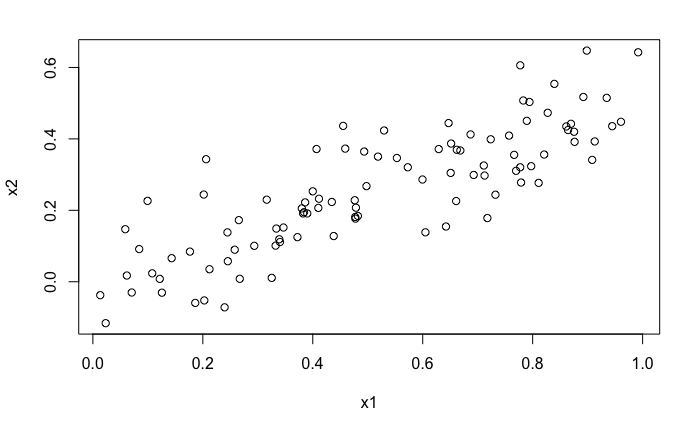

```r
plot(x1, x2)
```

## (c) Using the data, fit a least square regression to predict y using x1 and x2.

```r
summary(model3)
```

```
Call:
lm(formula = y ~ x1 + x2)

Residuals:
    Min      1Q  Median      3Q     Max
-2.8311 -0.7273 -0.0537  0.6338  2.3359

Coefficients:
            Estimate Std. Error t value Pr(>|t|)
(Intercept)   2.1305     0.2319   9.188 7.61e-15 ***
x1            1.4396     0.7212   1.996   0.0487 *
x2            1.0097     1.1337   0.891   0.3754
---
Signif. codes:  0 '***' 0.001 '**' 0.01 '*' 0.05 '.' 0.1 ' ' 1

Residual standard error: 1.056 on 97 degrees of freedom
Multiple R-squared:  0.2088,    Adjusted R-squared:  0.1925
F-statistic:  12.8 on 2 and 97 DF,  p-value: 1.164e-05
```

### What are the estimated parameters of ????0, ????1 and ????2? How do these relate to the true ??0, ??1 and ??

????0 is very close to the true ??0. However, the other 2 are not as close to their true values.

### How about the null hypothesis H0 : ??2 = 0?

It cannot be rejected.

## (d) Now fit a least squares regression to predict y using only x1.

```r
model4 <- lm(y ~ x1)
summary(model4)
```

```
Call:
lm(formula = y ~ x1)

Residuals:
     Min       1Q   Median       3Q      Max
-2.89495 -0.66874 -0.07785  0.59221  2.45560

Coefficients:
            Estimate Std. Error t value Pr(>|t|)
(Intercept)   2.1124     0.2307   9.155 8.27e-15 ***
x1            1.9759     0.3963   4.986 2.66e-06 ***
---
Signif. codes:  0 '***' 0.001 '**' 0.01 '*' 0.05 '.' 0.1 ' ' 1

Residual standard error: 1.055 on 98 degrees of freedom
Multiple R-squared:  0.2024,    Adjusted R-squared:  0.1942
F-statistic: 24.86 on 1 and 98 DF,  p-value: 2.661e-06
```

### How does the estimated ????1 relate to the true ??1?

They are very similar. In fact ????1 is 0.0241 off from the true ??1 of 2.

### Can you reject the null hypothesis H0 : ??1 = 0?

Yes, as the p-value is very close to 0

## (e) Now fit a least squares regression to predict y using only x2.

```r
model5 <- lm(y ~ x2)
summary(model5)
```

```
Call:
lm(formula = y ~ x2)

Residuals:
     Min       1Q   Median       3Q      Max
-2.62687 -0.75156 -0.03598  0.72383  2.44890

Coefficients:
            Estimate Std. Error t value Pr(>|t|)
(Intercept)   2.3899     0.1949   12.26  < 2e-16 ***
x2            2.8996     0.6330    4.58 1.37e-05 ***
---
Signif. codes:  0 '***' 0.001 '**' 0.01 '*' 0.05 '.' 0.1 ' ' 1

Residual standard error: 1.072 on 98 degrees of freedom
Multiple R-squared:  0.1763,    Adjusted R-squared:  0.1679
F-statistic: 20.98 on 1 and 98 DF,  p-value: 1.366e-05
```

### How does the estimated ????2 relate to the true ??2?

The value is very different from the true value of 0.3

### Can you reject the null hypothesis H0 : ??2 = 0?

Yes as the p-value is very close to 0

## (f) Provide an explanation on the results in parts (c)-(e).

There is multicollinearity in the data between x1 and x2. In doing multi- ple regression we see this effect where it is difficult to reject H0 : ??i = 0 (for one of the coefficients), while we see that with a single regression (with one variable), we can reject H0 : ??i = 0. This is caused by multicollinearity.